# User Profile Bayesian Analysis

This notebook analyzes the results of the Bayesian analysis of the user profile data.

We split our Bayesian analyses into three steps:

1. Exploratory analysis of data + preparation for sampling (notebook)
2. Sampling (Python script)
3. Analysis of sampling results (notebook)

This is to enable the sampling process and its results to be managed and cached by DVC, and to avoid re-running the Bayesian sampling process when we only want to change how we look at its results.

## Setup

```python
model = 'profile'
```

```python
# Parameters
model = "full"
```

```python
import os
from pathlib import Path
```

```python
import pandas as pd
import numpy as np
import scipy.special as sps
from scipy import stats
import seaborn as sns
import plotnine as p
import matplotlib.pyplot as plt
from statsmodels.nonparametric.kde import KDEUnivariate
import zarr
from IPython.display import display, Markdown
```

```python
from bookgender.config import rng_seed
from lenskit.util import init_rng
import bookgender.datatools as dt
from bookgender.nbutils import *
```

```python
seed = init_rng(rng_seed(), 'ProfileModelAnalysis', propagate=True)
rng = np.random.default_rng(seed)
seed
```

```
SeedSequence(
    entropy=261868553827208103807548308384201786360,
    spawn_key=(2851018176,),
)
```

```python
if model.startswith('profile'):
    fig_key = model
else:
    fig_key = 'profile-' + model
fig_key
```

```
'profile-full'
```

```python
fig_dir = init_figs(f'PMA-{fig_key}')
```

```
using figure dir figures\PMA-profile-full
```

## Load Data

```python
datasets = list(dt.datasets.keys())
datasets
```

```
['AZ', 'BX-E', 'BX-I', 'GR-E', 'GR-I']
```

We need to load the sampling results for each data set:

```python
samples = {}
summary = {}
for ds in datasets:
    _zf = zarr.ZipStore(f'data/{ds}/inference/{model}/samples.zarr', mode='r')
    _c = zarr.LRUStoreCache(_zf, 2**30)
    samples[ds] = zarr.group(_c)
    summary[ds] = pd.read_csv(f'data/{ds}/inference/{model}-summary.csv', index_col='name')
summary = pd.concat(summary, names=['Set'])
summary.head()
```

| Set | name | Mean | MCSE | StdDev | 5% | 50% | 95% | N_Eff | N_Eff/s | R_hat |
| --- | --- | --- | --- | --- | --- | --- | --- | --- | --- | --- |
| AZ | lp__ | -523430.000000 | 6.698110 | 230.681000 | -523811.000000 | -523434.000000 | -523047.000000 | 1186.09 | 0.171128 | 1.005420 |
|  | mu | -0.404199 | 0.000296 | 0.027883 | -0.449519 | -0.404244 | -0.357611 | 8846.61 | 1.276380 | 0.999921 |
|  | sigma | 1.817710 | 0.000500 | 0.025899 | 1.775350 | 1.817410 | 1.860390 | 2683.58 | 0.387183 | 1.000170 |
|  | nTheta[1] | 1.286780 | 0.004743 | 0.404129 | 0.623833 | 1.279880 | 1.964260 | 7258.89 | 1.047310 | 0.999970 |
|  | nTheta[2] | -0.690522 | 0.003429 | 0.316051 | -1.215020 | -0.687933 | -0.183888 | 8495.49 | 1.225720 | 1.000410 |

Extract and verify sample size:

```python
sample_size = len(samples['AZ']['lp__'])
assert all(len(s['lp__']) == sample_size for s in samples.values())
sample_size
```

```
10000
```

## Quality Checks

Do we have parameters with bad mixing? (high $\hat{R}$)

```python
summary.sort_values('R_hat', ascending=False).head()
```

| Set | name | Mean | MCSE | StdDev | 5% | 50% | 95% | N_Eff | N_Eff/s | R_hat |
| --- | --- | --- | --- | --- | --- | --- | --- | --- | --- | --- |
| AZ | recV[1] | 0.328336 | 0.000381 | 0.010875 | 0.310559 | 0.328422 | 0.346121 | 813.49 | 0.117369 | 1.00780 |
|  | recV[7] | 0.591941 | 0.000377 | 0.014596 | 0.567788 | 0.592029 | 0.615941 | 1495.08 | 0.215708 | 1.00557 |
|  | lp__ | -523430.000000 | 6.698110 | 230.681000 | -523811.000000 | -523434.000000 | -523047.000000 | 1186.09 | 0.171128 | 1.00542 |
| BX-I | log_lik[40] | -11.763600 | 0.026478 | 1.550820 | -14.768900 | -11.450300 | -9.857870 | 3430.33 | 0.728409 | 1.00472 |
| AZ | log_lik[1277] | -21.237200 | 0.035902 | 2.023170 | -25.041100 | -20.892700 | -18.590100 | 3175.55 | 0.458165 | 1.00453 |

Let's compute LPPD and WAIC for each of our models:

```python
def ll_stats(ds):
    ll_exp = samples[ds]['ll_exp']
    ll_var = samples[ds]['ll_var']
    lppd = np.sum(ll_exp)
    pwaic = np.sum(ll_var)
    return pd.Series({'lppd': lppd, 'pWAIC': pwaic, 'WAIC': -2 * (lppd - pwaic)})
pd.Series(datasets).apply(ll_stats).assign(Set=datasets).set_index('Set')
```

| Set | lppd | pWAIC | WAIC |
| --- | --- | --- | --- |
| AZ | -105183.705730 | 19923.413558 | 250214.238575 |
| BX-E | -35879.516478 | 7358.254564 | 86475.542083 |
| BX-I | -65591.503901 | 12595.357457 | 156373.722716 |
| GR-E | -40095.871232 | 7517.476264 | 95226.694992 |
| GR-I | -72305.932973 | 12602.205166 | 169816.276278 |

## Extract and Summarize

Extract sample data in a form usable for plotting:

```python
samp_df = pd.concat(dict((ds, pd.DataFrame({
    'Mu': samples[ds]['mu'],
    'Sigma': samples[ds]['sigma'],
    'Theta': samples[ds]['thetaP']
})) for ds in datasets), names=['Set']).copy()
samp_df
```

| Set |  | Mu | Sigma | Theta |
| --- | --- | --- | --- | --- |
| AZ | 0 | -0.428029 | 1.84320 | 0.014647 |
|  | 1 | -0.425898 | 1.78460 | 0.943089 |
|  | 2 | -0.402148 | 1.80616 | 0.164888 |
|  | 3 | -0.402499 | 1.78952 | 0.436446 |
|  | 4 | -0.408635 | 1.79498 | 0.820111 |
| ... | ... | ... | ... | ... |
| GR-I | 9995 | -0.256192 | 1.39657 | 0.843665 |
|  | 9996 | -0.269800 | 1.41944 | 0.546385 |
|  | 9997 | -0.267748 | 1.41610 | 0.789476 |
|  | 9998 | -0.200176 | 1.40139 | 0.204088 |
|  | 9999 | -0.238515 | 1.41414 | 0.615352 |

50000 rows × 3 columns

We also want to show observed distributions:

```python
profiles = pd.read_pickle('data/profile-data.pkl')
profiles.head()
```

| Set | user | count | linked | ambiguous | male | female | dcknown | dcyes | PropDC | Known | PropFemale | PropKnown |
| --- | --- | --- | --- | --- | --- | --- | --- | --- | --- | --- | --- | --- |
| AZ | 529 | 8 | 8 | 2 | 1 | 4 | 8 | 3 | 0.375000 | 5 | 0.800000 | 0.625000 |
|  | 1723 | 25 | 24 | 3 | 15 | 6 | 25 | 14 | 0.560000 | 21 | 0.285714 | 0.840000 |
|  | 1810 | 14 | 6 | 0 | 6 | 0 | 8 | 1 | 0.125000 | 6 | 0.000000 | 0.428571 |
|  | 2781 | 8 | 8 | 1 | 5 | 1 | 8 | 5 | 0.625000 | 6 | 0.166667 | 0.750000 |
|  | 2863 | 6 | 6 | 0 | 6 | 0 | 6 | 4 | 0.666667 | 6 | 0.000000 | 1.000000 |

For each sample, we want to sample a predicted observation. We do this by:

1. Sample $n'$ from the observed profile sizes
2. Sample $y' \sim \mathrm{Binomial}(n', \theta')$
3. Compute $y'/n'$

```python
def _sample_ns(df):
    known = profiles.loc[df.name, 'Known']
    # return known.sample(len(df), replace=True).reset_index(drop=True)
    return pd.Series(rng.choice(known, len(df)))
samp_df.groupby('Set').apply(_sample_ns).stack()
```

```
Set
AZ    0         6
      1         5
      2         9
      3         8
      4        22
             ...
GR-I  9995    124
      9996     27
      9997    338
      9998     33
      9999     37
Length: 50000, dtype: int32
```

```python
samp_df['N'] = samp_df.groupby('Set').apply(_sample_ns).stack()
samp_df['Y'] = rng.binomial(samp_df['N'], samp_df['Theta'], len(samp_df))
samp_df['PropFemale'] = samp_df['Y'] / samp_df['N']
samp_df.head()
```

| Set |  | Mu | Sigma | Theta | N | Y | PropFemale |
| --- | --- | --- | --- | --- | --- | --- | --- |
| AZ | 0 | -0.428029 | 1.84320 | 0.014647 | 5 | 0 | 0.000000 |
|  | 1 | -0.425898 | 1.78460 | 0.943089 | 17 | 16 | 0.941176 |
|  | 2 | -0.402148 | 1.80616 | 0.164888 | 17 | 2 | 0.117647 |
|  | 3 | -0.402499 | 1.78952 | 0.436446 | 44 | 17 | 0.386364 |
|  | 4 | -0.408635 | 1.79498 | 0.820111 | 11 | 10 | 0.909091 |

## Summarize Statistics and Parameters

We want to report summary statistics of the various parameters. We will start with observed ratios:

```python
profiles.groupby('Set')['PropFemale'].agg(['mean', 'std']).T
```

| Set | AZ | BX-E | BX-I | GR-E | GR-I |
| --- | --- | --- | --- | --- | --- |
| mean | 0.414445 | 0.418886 | 0.407030 | 0.446998 | 0.450201 |
| std | 0.329436 | 0.267354 | 0.254304 | 0.276480 | 0.269127 |

```python
print(profiles.groupby('Set')['PropFemale'].agg(['mean', 'std']).T.to_latex(float_format='%.3f'))
```

```
\begin{tabular}{lrrrrr}
\toprule
Set &    AZ &  BX-E &  BX-I &  GR-E &  GR-I \\
\midrule
mean & 0.414 & 0.419 & 0.407 & 0.447 & 0.450 \\
std  & 0.329 & 0.267 & 0.254 & 0.276 & 0.269 \\
\bottomrule
\end{tabular}
```

What about our est. mean log odds ($\mu$) and variance ($\sigma$)? We also want to the posterior mean tendancy ($\theta$) and its variance.

It's important to distinguish between the *estimated variance of users* ($\sigma$) and the *variance of the estimate* (e.g. the variance of $\mu$). Since $\theta$ is a sample of a random unseen user, its variance should be comparable to the variance of the underlying users.

```python
samp_df.groupby('Set')[['Mu', 'Sigma', 'Theta']].agg(['mean', 'std']).T
```

|  | Set | AZ | BX-E | BX-I | GR-E | GR-I |
| --- | --- | --- | --- | --- | --- | --- |
| Mu | mean | -0.404199 | -0.387693 | -0.436366 | -0.268155 | -0.239446 |
|  | std | 0.027883 | 0.019787 | 0.017108 | 0.022523 | 0.020677 |
| Sigma | mean | 1.817712 | 1.203551 | 1.087071 | 1.510577 | 1.407563 |
|  | std | 0.025899 | 0.019206 | 0.014878 | 0.018145 | 0.015249 |
| Theta | mean | 0.435515 | 0.424355 | 0.416129 | 0.452638 | 0.454304 |
|  | std | 0.295780 | 0.231262 | 0.217583 | 0.270602 | 0.261225 |

Find the 95% confidence intervals of $\mu$:

```python
samp_df.groupby('Set')['Mu'].apply(lambda s: {
    'Low': s.quantile(0.025),
    'High': s.quantile(0.975)
}).unstack()
```

| Set | Low | High |
| --- | --- | --- |
| AZ | -0.458947 | -0.350098 |
| BX-E | -0.426526 | -0.348723 |
| BX-I | -0.469878 | -0.403145 |
| GR-E | -0.311513 | -0.223671 |
| GR-I | -0.280169 | -0.198707 |

Let's look at the STAN summary output for these parameters too:

```python
summary.swaplevel().loc['mu', ['Mean', 'StdDev', '5%', '95%']].T
```

| Set | AZ | BX-E | BX-I | GR-E | GR-I |
| --- | --- | --- | --- | --- | --- |
| Mean | -0.404199 | -0.387693 | -0.436366 | -0.268155 | -0.239446 |
| StdDev | 0.027883 | 0.019787 | 0.017109 | 0.022523 | 0.020677 |
| 5% | -0.449519 | -0.419934 | -0.464393 | -0.304782 | -0.273687 |
| 95% | -0.357611 | -0.354885 | -0.408594 | -0.231050 | -0.205793 |

```python
summary.swaplevel().loc['sigma', ['Mean', 'StdDev', '5%', '95%']].T
```

| Set | AZ | BX-E | BX-I | GR-E | GR-I |
| --- | --- | --- | --- | --- | --- |
| Mean | 1.817710 | 1.203550 | 1.087070 | 1.510580 | 1.407560 |
| StdDev | 0.025899 | 0.019206 | 0.014878 | 0.018145 | 0.015249 |
| 5% | 1.775350 | 1.172050 | 1.062880 | 1.480830 | 1.382450 |
| 95% | 1.860390 | 1.235130 | 1.111600 | 1.541110 | 1.432750 |

```python
summary.swaplevel().loc['thetaP', ['Mean', 'StdDev', '5%', '95%']].T
```

| Set | AZ | BX-E | BX-I | GR-E | GR-I |
| --- | --- | --- | --- | --- | --- |
| Mean | 0.435515 | 0.424355 | 0.416129 | 0.452638 | 0.454304 |
| StdDev | 0.295780 | 0.231262 | 0.217583 | 0.270602 | 0.261225 |
| 5% | 0.032316 | 0.089250 | 0.097087 | 0.062216 | 0.070188 |
| 95% | 0.931554 | 0.827087 | 0.798405 | 0.900807 | 0.888453 |

## Plot Distributions

Stack simulated proportions from two sources:

```python
simulated_prop = pd.DataFrame({'value': samp_df[['Theta', 'PropFemale']].stack()})
simulated_prop.reset_index([0,2], inplace=True)
simulated_prop['Set'] = simulated_prop['Set'].astype('category')
simulated_prop.rename(columns={'level_2': 'Method'}, inplace=True)
simulated_prop.reset_index(drop=True, inplace=True)
simulated_prop.head()
```

|  | Set | Method | value |
| --- | --- | --- | --- |
| 0 | AZ | Theta | 0.014647 |
| 1 | AZ | PropFemale | 0.000000 |
| 2 | AZ | Theta | 0.943089 |
| 3 | AZ | PropFemale | 0.941176 |
| 4 | AZ | Theta | 0.164888 |

```python
obs_prop = profiles.groupby('Set').apply(lambda df: df['PropFemale'].sample(sample_size, replace=True))
obs_prop.name = 'value'
obs_prop = obs_prop.reset_index(0)
obs_prop.reset_index(drop=True, inplace=True)
obs_prop['Method'] = 'Observed'
obs_prop = obs_prop[['Set', 'Method', 'value']]
obs_prop.head()
```

|  | Set | Method | value |
| --- | --- | --- | --- |
| 0 | AZ | Observed | 0.071429 |
| 1 | AZ | Observed | 0.411765 |
| 2 | AZ | Observed | 0.285714 |
| 3 | AZ | Observed | 0.142857 |
| 4 | AZ | Observed | 1.000000 |

```python
all_prop = pd.concat([simulated_prop, obs_prop], ignore_index=True)
all_prop['Method'] = all_prop['Method'].astype('category')
all_prop['Method'].cat.reorder_categories(['Theta', 'PropFemale', 'Observed'], inplace=True)
all_prop['Method'].cat.rename_categories({'Theta': 'Smoothed', 'PropFemale': 'Predicted y/n', 'Observed': 'Observed y/n'}, inplace=True)
all_prop.head()
```

|  | Set | Method | value |
| --- | --- | --- | --- |
| 0 | AZ | Smoothed | 0.014647 |
| 1 | AZ | Predicted y/n | 0.000000 |
| 2 | AZ | Smoothed | 0.943089 |
| 3 | AZ | Predicted y/n | 0.941176 |
| 4 | AZ | Smoothed | 0.164888 |

We want the mean for each method to show:

```python
prop_means = all_prop.groupby(['Set', 'Method'])['value'].mean().reset_index()
prop_means
```

|  | Set | Method | value |
| --- | --- | --- | --- |
| 0 | AZ | Smoothed | 0.435515 |
| 1 | AZ | Predicted y/n | 0.434736 |
| 2 | AZ | Observed y/n | 0.415003 |
| 3 | BX-E | Smoothed | 0.424355 |
| 4 | BX-E | Predicted y/n | 0.424520 |
| 5 | BX-E | Observed y/n | 0.420246 |
| 6 | BX-I | Smoothed | 0.416129 |
| 7 | BX-I | Predicted y/n | 0.414873 |
| 8 | BX-I | Observed y/n | 0.404499 |
| 9 | GR-E | Smoothed | 0.452638 |
| 10 | GR-E | Predicted y/n | 0.452408 |
| 11 | GR-E | Observed y/n | 0.446901 |
| 12 | GR-I | Smoothed | 0.454304 |
| 13 | GR-I | Predicted y/n | 0.454035 |
| 14 | GR-I | Observed y/n | 0.448502 |

Now finally we can view densities:

```
(0.0, 1.0)
```

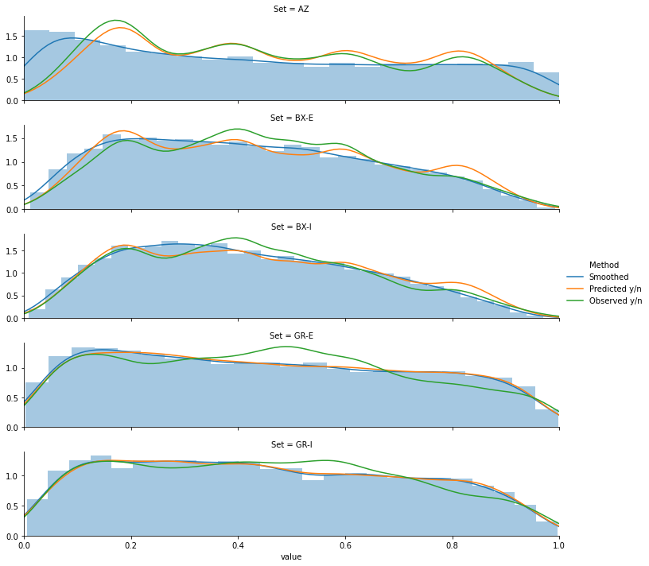

```python
grid = sns.FacetGrid(all_prop.assign(hist=all_prop.Method == 'Observed y/n'), row='Set', hue='Method',
                     sharey=False, height=2, aspect=5)
for (r, c, h), df in grid.facet_data():
    if h == 0:
        sns.distplot(df['value'], kde=False, norm_hist=True, ax=grid.axes[r, c])
grid.map(sns.kdeplot, 'value', clip=(0,1)).add_legend()
plt.xlim(0, 1)
# plt.savefig(fig_dir / 'dist.pdf')
```

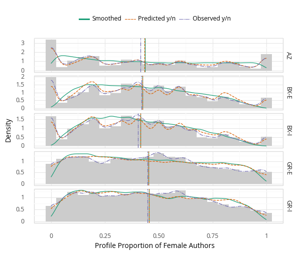

```python
from bookgender.nbutils import make_plot
make_plot(all_prop, p.aes('value'),
          p.geom_histogram(p.aes(y='..density..'), data=obs_prop,
                           binwidth=0.05, fill='#CCCCCC'),
          p.geom_line(p.aes(color='Method', linetype='Method'),
                      stat='density', bw='scott', adjust=0.5),
          p.geom_vline(p.aes(xintercept='value', color='Method', linetype='Method'),
                       data=prop_means, show_legend=False),
          p.facet_grid('Set ~', scales='free_y'),
          p.scale_color_brewer('qual', 'Dark2'),
          p.xlab("Profile Proportion of Female Authors"),
          p.ylab("Density"),
          legend_position='top', legend_title=p.element_blank(),
          file='profile-dist', width=8, height=6)
```

## Robustness of Individual Inferences

The profiling process infers a $g(\theta_u)$ value for each user. What is the variance of those estimates?

```python
def u_stats(ds):
    ths = samples[ds]['nTheta'][...].T
    return pd.DataFrame({
        'mean': np.mean(ths, axis=1),
        'var': np.var(ths, axis=1),
        'lo': np.quantile(ths, 0.025, axis=1),
        'hi': np.quantile(ths, 0.975, axis=1)
    })
user_biases = pd.concat(dict(
    (ds, u_stats(ds)) for ds in datasets
), names=['Set', 'uidx'])
user_biases
```

| Set | uidx | mean | var | lo | hi |
| --- | --- | --- | --- | --- | --- |
| AZ | 0 | 1.286784 | 0.163304 | 0.509874 | 2.102445 |
|  | 1 | -0.690522 | 0.099878 | -1.324202 | -0.083863 |
|  | 2 | -2.271919 | 0.298153 | -3.386939 | -1.259787 |
|  | 3 | -2.178549 | 0.194462 | -3.054623 | -1.328799 |
|  | 4 | -1.654363 | 0.160850 | -2.455701 | -0.878510 |
| ... | ... | ... | ... | ... | ... |
| GR-I | 4995 | 1.085391 | 0.002662 | 0.985604 | 1.189203 |
|  | 4996 | -1.429757 | 0.098418 | -2.040010 | -0.822707 |
|  | 4997 | -0.853467 | 0.033602 | -1.219776 | -0.503246 |
|  | 4998 | 1.524129 | 0.026841 | 1.206189 | 1.848613 |
|  | 4999 | -2.015394 | 0.023908 | -2.325380 | -1.719341 |

25000 rows × 4 columns

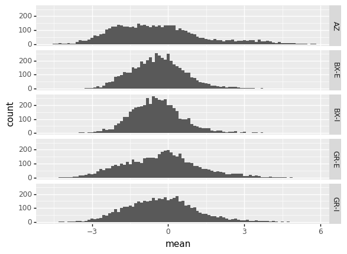

```python
(p.ggplot(user_biases.reset_index(), p.aes('mean'))
 + p.geom_histogram()
 + p.facet_grid('Set ~'))
```

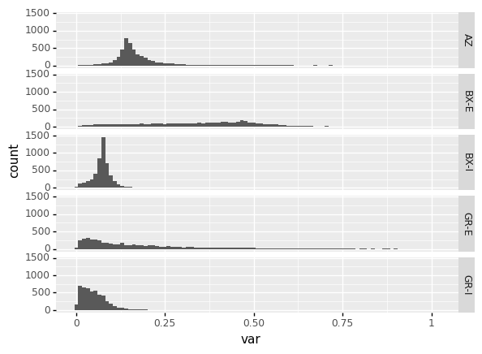

```python
(p.ggplot(user_biases.reset_index(), p.aes('var'))
 + p.geom_histogram()
 + p.facet_grid('Set ~'))
```

This indicates quite a few $\theta_u$ values have high posterior variance, so we really do want to use the entire distribution.